# Model Assessment and Comparisons (WAIC)

Sudipto Banerjee

*Note:* To generate this HTML file, run `renderRaw.sh` in the terminal from the `src/bayesianLinearRegressionExact/raw/run` directory. Alternatively, find the source `Rmd` and `R` files in that same folder starting from the `BGC_2023` GitHub home.

```bash
# Navigate to the directory and run the compilation script
cd src/bayesianLinearRegressionExact/raw/run
./renderRaw.sh
```

Model selection and assessment are central to Bayesian data analysis. The **Watanabe-Akaike Information Criterion (WAIC)**—also known as the *Widely Applicable Information Criterion*—is a fully Bayesian metric for estimating out-of-sample predictive accuracy. Unlike the Akaike Information Criterion (AIC) or Deviance Information Criterion (DIC), WAIC utilizes the full posterior distribution (rather than point estimates) and is valid for complex, non-linear, or singular models.

WAIC is defined on the deviance scale as:

$$\text{WAIC} = -2 \left( lppd -
p_{\text{WAIC}} \right)$$

where: * $lppd$ is the **log point predictive density**, measuring model fit. * $p_{\text{WAIC}}$ is the **effective number of parameters**, penalizing model complexity.

## 1. Exact Closed-Form Derivation of $lppd$

The log point predictive density is defined analytically as:

$$lppd_{\text{exact}} = \sum_{i=1}^n \log
p(y_i \mid y) = \sum_{i=1}^n \log \left( \iint p(y_i \mid \beta,
\sigma^2) \, p(\beta, \sigma^2 \mid y) \, d\beta \, d\sigma^2
\right)$$

### Posterior Parameters of the Conjugate Model

Under the conjugate prior setup:

$$\begin{aligned}
\sigma^2 &\sim \text{Inverse-Gamma}(a_0, b_0) \\
\beta \mid \sigma^2 &\sim \mathcal{N}_p\left(m_0, \, \sigma^2
M_0\right)
\end{aligned}$$

The joint posterior distribution is Normal-Inverse-Gamma, $p(\beta, \sigma^2 \mid y) = \mathcal{N}_p(\mu_\beta, \sigma^2 M) \times \text{Inverse-Gamma}(a^*, b^*)$, where:

$$\begin{aligned}
M &= \left(M_0^{-1} + X^\top X\right)^{-1} \\
\mu_\beta &= M \left(M_0^{-1} m_0 + X^\top y\right) \quad
\text{(Posterior mean of } \beta\text{)} \\
a^* &= a_0 + \frac{n}{2} \\
b^* &= b_0 + \frac{1}{2} \left[ y^\top y + m_0^\top M_0^{-1} m_0 -
\mu_\beta^\top M^{-1} \mu_\beta \right]
\end{aligned}$$

### Step 1: Conditional Density Given $\sigma^2$

For an in-sample observation $y_i = x_i^\top \beta + \epsilon_i$ (where $x_i^\top$ is the $i$-th row of $X$), conditioning on $\sigma^2$ and integrating over $\beta$ yields:

$$\mathbb{E}[y_i \mid \sigma^2, y] =
x_i^\top \mathbb{E}[\beta \mid \sigma^2, y] = x_i^\top
\mu_\beta$$

$$\text{Var}(y_i \mid \sigma^2, y) =
x_i^\top \text{Var}(\beta \mid \sigma^2, y) x_i + \sigma^2 = \sigma^2
\left(1 + x_i^\top M x_i\right)$$

Letting $h_i = 1 + x_i^\top M x_i$ (a leverage factor reflecting posterior covariance on observation $i$), the conditional distribution is:

$$y_i \mid \sigma^2, y \sim
\mathcal{N}\left(x_i^\top \mu_\beta, \, \sigma^2 h_i\right)$$

### Step 2: Marginalizing Out Variance $\sigma^2$

Marginalizing $y_i$ over the Inverse-Gamma posterior $p(\sigma^2 \mid y) = \frac{(b^*)^{a^*}}{\Gamma(a^*)} (\sigma^2)^{-(a^* + 1)} \exp\left(-\frac{b^*}{\sigma^2}\right)$:

$$p(y_i \mid y) = \int_0^\infty
\frac{1}{\sqrt{2\pi \sigma^2 h_i}} \exp\left( -\frac{(y_i - x_i^\top
\mu_\beta)^2}{2 \sigma^2 h_i} \right) \frac{(b^*)^{a^*}}{\Gamma(a^*)}
(\sigma^2)^{-(a^* + 1)} \exp\left(-\frac{b^*}{\sigma^2}\right)
d\sigma^2$$

Combining powers of $\sigma^2$ and exponential terms inside the integral:

$$p(y_i \mid y) =
\frac{(b^*)^{a^*}}{\Gamma(a^*) \sqrt{2\pi h_i}} \int_0^\infty
(\sigma^2)^{-\left(a^* + \frac{1}{2} + 1\right)} \exp\left(
-\frac{1}{\sigma^2} \left[ b^* + \frac{(y_i - x_i^\top \mu_\beta)^2}{2
h_i} \right] \right) d\sigma^2$$

Recognizing the kernel of an Inverse-Gamma distribution with shape $a^* + \frac{1}{2}$ and scale $b^* + \frac{(y_i - x_i^\top \mu_\beta)^2}{2 h_i}$, the integral evaluates to:

$$p(y_i \mid y) =
\frac{(b^*)^{a^*}}{\Gamma(a^*) \sqrt{2\pi h_i}} \cdot
\frac{\Gamma\left(a^* + \frac{1}{2}\right)}{\left[ b^* + \frac{(y_i -
x_i^\top \mu_\beta)^2}{2 h_i} \right]^{a^* + \frac{1}{2}}}$$

Rearranging terms:

$$p(y_i \mid y) = \frac{\Gamma\left(a^* +
\frac{1}{2}\right)}{\Gamma(a^*) \sqrt{2\pi b^* h_i}} \left( 1 +
\frac{(y_i - x_i^\top \mu_\beta)^2}{2 b^* h_i} \right)^{-\left(a^* +
\frac{1}{2}\right)}$$

This corresponds exactly to a non-standardized **univariate Student’s $t$-distribution** $t_{\nu}(\mu_i, s_i^2)$ with: * Degrees of freedom: $\nu = 2a^*$ * Location parameter: $\mu_i = x_i^\top \mu_\beta$ * Scale parameter squared: $s_i^2 = \frac{b^*}{a^*} h_i = \frac{b^*}{a^*}\left(1 + x_i^\top M x_i\right)$

### Step 3: Exact Closed-Form $lppd$ Formula

Taking the natural logarithm and summing over all $n$ observations gives the exact analytical formula:

$$lppd_{\text{exact}} = \sum_{i=1}^n
\left[ \log \Gamma\left(a^* + \frac{1}{2}\right) - \log \Gamma(a^*) -
\frac{1}{2} \log\left(2\pi b^* h_i\right) - \left(a^* +
\frac{1}{2}\right) \log\left( 1 + \frac{(y_i - x_i^\top \mu_\beta)^2}{2
b^* h_i} \right) \right]$$

## 2. Exact Closed-Form Derivation of $p_{\text{WAIC}}$

While $p_{\text{WAIC}}$ is typically evaluated via sample statistics, for conjugate Bayesian linear regression it can also be calculated in **exact closed form** using the Law of Total Variance over the posterior parameters $(\beta, \sigma^2)$.

We evaluate the posterior variance of the log-likelihood for observation $i$:

$$\text{Var}_{\beta, \sigma^2 \mid
y}(LL_i) = \text{Var}_{\beta, \sigma^2 \mid y} \left(
-\frac{1}{2}\log(2\pi) - \frac{1}{2}\log\sigma^2 - \frac{(y_i - x_i^\top
\beta)^2}{2\sigma^2} \right)$$

Let $e_i = y_i - x_i^\top \mu_\beta$ denote the posterior mean residual and $k_i = x_i^\top M x_i$ denote the leverage of observation $i$.

### Step 1: Conditioning on $\sigma^2$ (Inner Moments)

For a fixed $\sigma^2$, the conditional distribution is $y_i - x_i^\top \beta \sim \mathcal{N}(e_i, \sigma^2 k_i)$:

1. **Conditional Expectation:**
   $$\mathbb{E}_{\beta \mid \sigma^2, y}[LL_i] =
   -\frac{1}{2}\log(2\pi) - \frac{1}{2}\log\sigma^2 - \frac{e_i^2 +
   \sigma^2 k_i}{2\sigma^2} = -\frac{1}{2}\log(2\pi) -
   \frac{1}{2}\log\sigma^2 - \frac{e_i^2}{2\sigma^2} -
   \frac{k_i}{2}$$
2. **Conditional Variance:** Using the variance property of non-central chi-squared quadratic forms $\text{Var}\left((y_i - x_i^\top \beta)^2\right) = 2(\sigma^2 k_i)^2 + 4(\sigma^2 k_i)e_i^2$:
   $$\text{Var}_{\beta \mid \sigma^2, y}(LL_i) =
   \frac{1}{4\sigma^4} \left[ 2\sigma^4 k_i^2 + 4\sigma^2 k_i e_i^2 \right]
   = \frac{k_i^2}{2} + \frac{k_i e_i^2}{\sigma^2}$$

### Step 2: Applying the Law of Total Variance over $\sigma^2 \mid y$

$$\text{Var}_{\beta, \sigma^2 \mid
y}(LL_i) = \underbrace{\mathbb{E}_{\sigma^2 \mid y}\left[
\text{Var}_{\beta \mid \sigma^2, y}(LL_i) \right]}_{\text{Term 1}} +
\underbrace{\text{Var}_{\sigma^2 \mid y}\left( \mathbb{E}_{\beta \mid
\sigma^2, y}[LL_i] \right)}_{\text{Term 2}}$$

#### Evaluating Term 1:

Using $\mathbb{E}\left[\frac{1}{\sigma^2}\right] = \frac{a^*}{b^*}$ under $\sigma^2 \mid y \sim \text{Inverse-Gamma}(a^*, b^*)$:
$$\text{Term 1} = \mathbb{E}_{\sigma^2 \mid
y}\left[ \frac{k_i^2}{2} + \frac{k_i e_i^2}{\sigma^2} \right] =
\frac{k_i^2}{2} + \frac{a^* k_i e_i^2}{b^*}$$

#### Evaluating Term 2:

Expanding the variance of the conditional expectation:
$$\text{Term 2} = \text{Var}_{\sigma^2 \mid
y}\left( -\frac{1}{2}\log\sigma^2 - \frac{e_i^2}{2\sigma^2} \right) =
\frac{1}{4}\text{Var}(\log\sigma^2) +
\frac{e_i^4}{4}\text{Var}\left(\frac{1}{\sigma^2}\right) +
\frac{e_i^2}{2}\text{Cov}\left(\log\sigma^2,
\frac{1}{\sigma^2}\right)$$

Under precision $\tau = \frac{1}{\sigma^2} \sim \text{Gamma}(a^*, b^*)$: * $\text{Var}(\log\sigma^2) = \text{Var}(\log\tau) = \psi^{(1)}(a^*)$ *(where $\psi^{(1)}$ is the **trigamma function**)* * $\text{Var}\left(\frac{1}{\sigma^2}\right) = \text{Var}(\tau) = \frac{a^*}{(b^*)^2}$ * $\text{Cov}\left(\log\sigma^2, \frac{1}{\sigma^2}\right) = \text{Cov}(-\log\tau, \tau) = -\frac{1}{b^*}$

Substituting these exact identities into Term 2:
$$\text{Term 2} = \frac{1}{4} \psi^{(1)}(a^*) +
\frac{a^* e_i^4}{4 (b^*)^2} - \frac{e_i^2}{2 b^*}$$

### Step 3: Exact Closed-Form $p_{\text{WAIC}}$ Formula

Combining **Term 1** and **Term 2** yields the exact pointwise log-likelihood variance:

$$\text{Var}(LL_i) = \frac{k_i^2}{2} +
\frac{a^* k_i e_i^2}{b^*} + \frac{1}{4} \psi^{(1)}(a^*) + \frac{a^*
e_i^4}{4 (b^*)^2} - \frac{e_i^2}{2 b^*}$$

Summing over all $n$ observations provides the exact analytical effective number of parameters:

$$p_{\text{WAIC}, \text{exact}} =
\sum_{i=1}^n \left[ \frac{k_i^2}{2} + \frac{a^* k_i e_i^2}{b^*} +
\frac{1}{4} \psi^{(1)}(a^*) + \frac{a^* e_i^4}{4 (b^*)^2} -
\frac{e_i^2}{2 b^*} \right]$$

Thus, the **exact closed-form WAIC** is given by:

$$\text{WAIC}_{\text{exact}} = -2 \left(
lppd_{\text{exact}} - p_{\text{WAIC}, \text{exact}} \right)$$

## 3. Sample-Based Computation of WAIC

When using posterior draws $\theta^{(s)} = \left(\beta^{(s)}, \sigma^{2(s)}\right)$ for $s = 1, \ldots, N$, WAIC is evaluated empirically using the **pointwise log-likelihood matrix** $LL \in \mathbb{R}^{n \times N}$.

The log-likelihood entry for observation $i$ under draw $s$ is:

$$LL_{i,s} = \log p\left(y_i \mid
\beta^{(s)}, \sigma^{2(s)}\right) = -\frac{1}{2} \log\left(2\pi
\sigma^{2(s)}\right) - \frac{\left(y_i - x_i^\top
\beta^{(s)}\right)^2}{2 \sigma^{2(s)}}$$

### Pointwise Predictive Density ($lppd_{\text{sample}}$)

The sample-based estimate averages likelihoods across all MCMC draws prior to taking the logarithm:

$$lppd_{\text{sample}} = \sum_{i=1}^n \log
\left( \frac{1}{N} \sum_{s=1}^N p\left(y_i \mid \beta^{(s)},
\sigma^{2(s)}\right) \right) = \sum_{i=1}^n \log \left( \frac{1}{N}
\sum_{s=1}^N \exp\left(LL_{i,s}\right) \right)$$

### Model Complexity Penalty ($p_{\text{WAIC}}$)

The empirical effective number of parameters ($p_{\text{WAIC}, 2}$) calculates the sample variance of the log-likelihood across posterior draws for each observation $i$:

$$p_{\text{WAIC}} = \sum_{i=1}^n V_{s=1}^N
\left( LL_{i,s} \right)$$

where the operator $V_{s=1}^N \left( LL_{i,s} \right)$ represents the sample variance for observation $i$:

$$V_{s=1}^N \left( LL_{i,s} \right) =
\frac{1}{N - 1} \sum_{s=1}^N \left( LL_{i,s} - \bar{LL}_i
\right)^2$$

and $\bar{LL}_i = \frac{1}{N} \sum_{s=1}^N LL_{i,s}$ is the sample mean log-likelihood for observation $i$.

## 4. Numerical Stability: The Log-Sum-Exp Trick

Computing $\log \left( \frac{1}{N} \sum_{s=1}^N \exp(LL_{i,s}) \right)$ directly in standard floating-point arithmetic easily causes **numerical underflow** (if $LL_{i,s}$ values are highly negative, $\exp(LL_{i,s}) \to 0$) or **overflow**.

To ensure numerical stability, we apply the **Log-Sum-Exp identity**:

Let $c_i = \max_{s \in \{1, \ldots, N\}} LL_{i,s}$.

$$\begin{aligned}
\log \left( \frac{1}{N} \sum_{s=1}^N \exp(LL_{i,s}) \right) &= \log
\left( \frac{1}{N} \exp(c_i) \sum_{s=1}^N \exp(LL_{i,s} - c_i) \right)
\\
&= c_i - \log(N) + \log \left( \sum_{s=1}^N \exp\left(LL_{i,s} -
c_i\right) \right)
\end{aligned}$$

Because $LL_{i,s} - c_i \le 0$, the exponential terms $\exp(LL_{i,s} - c_i)$ are strictly bounded in $(0, 1]$, completely eliminating overflow and preventing underflow for all dominant posterior draws.

```r
# -----------------------------------------------------------------------------
# 1. Source Libraries & Routines
# -----------------------------------------------------------------------------
source("../src/rawSampler.r")
source("../src/modelComparisons.r")

# -----------------------------------------------------------------------------
# 2. Load Data and Setup Model Matrices
# -----------------------------------------------------------------------------
dataset <- read.table("../../data/data.txt", header = TRUE)

y_train <- dataset[, 1]
X_train_raw <- as.matrix(dataset[, -1])

X_train <- cbind(Intercept = 1, scale(X_train_raw))
n <- nrow(X_train)
p <- ncol(X_train)

# Prior specifications
m0     <- matrix(0, p, 1)
M0_inv <- matrix(0, p, p)  # Non-informative prior precision
a0     <- -p / 2
b0     <- 0
N_draws <- 10000

# -----------------------------------------------------------------------------
# 3. Fit Model & Generate Posterior Draws
# -----------------------------------------------------------------------------
set.seed(42)
posterior <- rawSampler(
  y = y_train,
  X = X_train,
  m0 = m0,
  M0_inv = M0_inv,
  a0 = a0,
  b0 = b0,
  N = N_draws
)

beta_draws   <- posterior$draws[, 1:p]
sigma2_draws <- posterior$draws[, "sigma2"]

# -----------------------------------------------------------------------------
# 4. Method (i): Exact Analytical WAIC
# -----------------------------------------------------------------------------
res_exact <- waic_exact(
  X = X_train,
  y = y_train,
  m0 = m0,
  M0_inv = M0_inv,
  a0 = a0,
  b0 = b0
)

# -----------------------------------------------------------------------------
# 5. Method (ii): Raw Sample-Based WAIC (with Log-Sum-Exp Trick)
# -----------------------------------------------------------------------------
LL_matrix <- compute_log_likelihood_matrix(
  X = X_train,
  y = y_train,
  beta_draws = beta_draws,
  sigma2_draws = sigma2_draws
)

res_sample <- waic_sample(LL_matrix)

# -----------------------------------------------------------------------------
# 6. Method (iii): 'loo' Package WAIC
# -----------------------------------------------------------------------------
res_loo <- waic_loo_package(LL_matrix)

# -----------------------------------------------------------------------------
# 7. Print Comparative Performance Summary
# -----------------------------------------------------------------------------
comparison_df <- data.frame(
  Metric = c("lppd (Log Predictive Density)", "p_WAIC (Effective Parameters)", "WAIC (Deviance Scale)"),
  `Exact_Analytical` = c(res_exact$lppd, res_exact$p_waic, res_exact$waic),
  `Raw_Sample_MCMC`  = c(res_sample$lppd, res_sample$p_waic, res_sample$waic),
  `LOO_Package`       = c(res_loo$lppd, res_loo$p_waic, res_loo$waic),
  `Abs_Diff_(Exact_vs_Sample)` = c(
    abs(res_exact$lppd - res_sample$lppd),
    abs(res_exact$p_waic - res_sample$p_waic),
    abs(res_exact$waic - res_sample$waic)
  )
)

knitr::kable(
  comparison_df,
  digits = 4,
  col.names = c("Metric", "Exact Analytical", "Raw Sample (Log-Sum-Exp)", "loo Package", "Abs Diff (Exact vs Raw)"),
  caption = "Comparison of WAIC Calculations across Analytical, Sample-Based, and 'loo' Methods"
)
```

Comparison of WAIC Calculations across Analytical, Sample-Based, and ‘loo’ Methods

| Metric | Exact Analytical | Raw Sample (Log-Sum-Exp) | loo Package | Abs Diff (Exact vs Raw) |
| --- | --- | --- | --- | --- |
| lppd (Log Predictive Density) | 648.2689 | 648.2678 | 648.2678 | 0.0011 |
| p_WAIC (Effective Parameters) | 11.2940 | 11.3611 | 11.3611 | 0.0671 |
| WAIC (Deviance Scale) | -1273.9497 | -1273.8133 | -1273.8133 | 0.1364 |

## 5. Sequential Model Comparison & Visualization

To observe how $lppd$, $p_{\text{WAIC}}$, and total $\text{WAIC}$ evolve as parameters are added, we evaluate a sequence of nested Bayesian regression models:

- **$M_0$**: Intercept only ($\beta_0$)
- **$M_1$**: Intercept + $X_1$
- **$M_2$**: Intercept + $X_1 + X_2$
- $\vdots$
- **$M_p$**: Full model with all $p$ predictors

Because $p_{\text{WAIC}, \text{exact}}$ and $lppd_{\text{exact}}$ give closed-form results instantly, we compute the exact metrics across all model sub-structures.

```r
library(ggplot2)
library(dplyr)
library(tidyr)

# -----------------------------------------------------------------------------
# 1. Fit Sequential Models M_0 to M_p
# -----------------------------------------------------------------------------
num_features <- ncol(X_train_raw)
model_results <- vector("list", num_features + 1)

for (k in 0:num_features) {
  if (k == 0) {
    X_k <- X_train[, 1, drop = FALSE] # Intercept only
    model_label <- "M0 (Intercept)"
  } else {
    X_k <- X_train[, 1:(k + 1), drop = FALSE] # Intercept + X1 + ... + Xk
    model_label <- paste0("M", k, " (+X", k, ")")
  }

  p_k <- ncol(X_k)

  # Hyperparameters for subset model k
  m0_k     <- matrix(0, p_k, 1)
  M0_inv_k <- matrix(0, p_k, p_k)
  a0_k     <- -p_k / 2
  b0_k     <- 0

  # Exact WAIC calculation
  res_k <- waic_exact(
    X = X_k,
    y = y_train,
    m0 = m0_k,
    M0_inv = M0_inv_k,
    a0 = a0_k,
    b0 = b0_k
  )

  model_results[[k + 1]] <- data.frame(
    Model_Index = k,
    Model       = model_label,
    Num_Params  = p_k + 1,  # p_k regression coefficients + 1 variance
    lppd        = res_k$lppd,
    p_waic      = res_k$p_waic,
    WAIC        = res_k$waic
  )
}

seq_df <- bind_rows(model_results)

# -----------------------------------------------------------------------------
# 2. Display Model Assessment Table
# -----------------------------------------------------------------------------
best_model_idx <- which.min(seq_df$WAIC)

knitr::kable(
  seq_df,
  digits = 3,
  col.names = c("Index", "Model Structure", "True Params (p+1)", "lppd (Fit)", "p_WAIC (Penalty)", "WAIC (Deviance)"),
  caption = "Sequential Bayesian Model Assessment (Closed-Form Exact WAIC)"
)
```

Sequential Bayesian Model Assessment (Closed-Form Exact WAIC)

| Index | Model Structure | True Params (p+1) | lppd (Fit) | p_WAIC (Penalty) | WAIC (Deviance) |
| --- | --- | --- | --- | --- | --- |
| 0 | M0 (Intercept) | 2 | -492.925 | 2.197 | 990.243 |
| 1 | M1 (+X1) | 3 | 518.995 | 3.211 | -1031.568 |
| 2 | M2 (+X2) | 4 | 528.838 | 4.149 | -1049.378 |
| 3 | M3 (+X3) | 5 | 555.625 | 5.350 | -1100.550 |
| 4 | M4 (+X4) | 6 | 583.924 | 6.248 | -1155.351 |
| 5 | M5 (+X5) | 7 | 588.926 | 7.246 | -1163.361 |
| 6 | M6 (+X6) | 8 | 616.935 | 8.847 | -1216.175 |
| 7 | M7 (+X7) | 9 | 626.120 | 10.109 | -1232.023 |
| 8 | M8 (+X8) | 10 | 648.269 | 11.294 | -1273.950 |

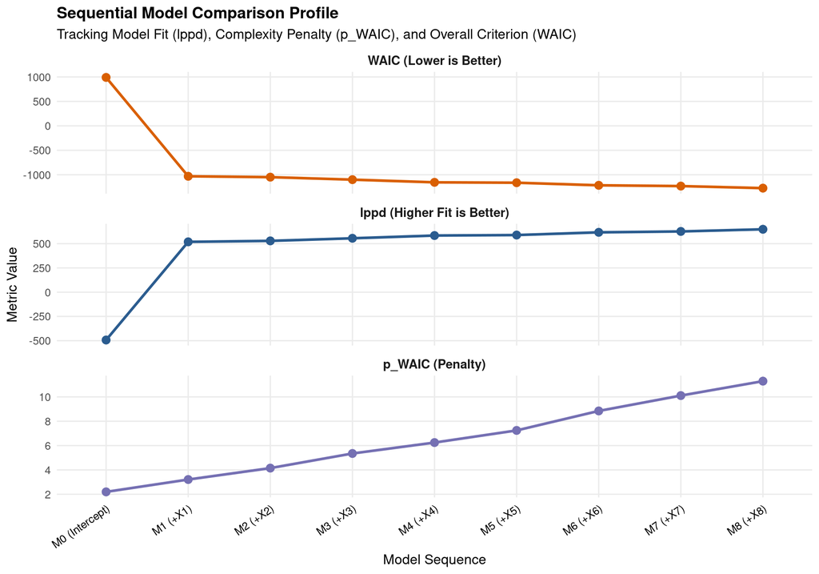

```r
# -----------------------------------------------------------------------------
# 3. Plot A: Faceted Metrics Overview
# -----------------------------------------------------------------------------
df_long <- seq_df %>%
  pivot_longer(
    cols = c("lppd", "p_waic", "WAIC"),
    names_to = "Metric",
    values_to = "Value"
  ) %>%
  mutate(
    Metric_Label = factor(
      Metric,
      levels = c("WAIC", "lppd", "p_waic"),
      labels = c("WAIC (Lower is Better)", "lppd (Higher Fit is Better)", "p_WAIC (Penalty)")
    ),
    Model = factor(Model, levels = seq_df$Model)
  )

p1 <- ggplot(df_long, aes(x = Model, y = Value, group = Metric_Label, color = Metric_Label)) +
  geom_line(linewidth = 1.1) +
  geom_point(size = 3) +
  facet_wrap(~ Metric_Label, scales = "free_y", ncol = 1) +
  scale_color_manual(values = c("WAIC (Lower is Better)" = "#d95f02",
                               "lppd (Higher Fit is Better)" = "#2b5c8f",
                               "p_WAIC (Penalty)" = "#7570b3")) +
  theme_minimal(base_size = 12) +
  theme(
    legend.position = "none",
    strip.text = element_text(face = "bold", size = 11),
    axis.text.x = element_text(angle = 35, hjust = 1, color = "black"),
    panel.grid.minor = element_blank(),
    plot.title = element_text(face = "bold", size = 14)
  ) +
  labs(
    title = "Sequential Model Comparison Profile",
    subtitle = "Tracking Model Fit (lppd), Complexity Penalty (p_WAIC), and Overall Criterion (WAIC)",
    x = "Model Sequence",
    y = "Metric Value"
  )

print(p1)
```

### Methodological Note: How WAIC Estimates Out-of-Sample Performance

A fundamental challenge in statistical modeling is evaluating how well a model will generalize to *new, unseen data* ($y^{\text{rep}}$) drawn from the true data-generating process $f(y)$.

Evaluating predictive accuracy directly on training data yields an overly optimistic assessment because the posterior distribution is optimized using those exact same observations. While cross-validation addresses this by physically partitioning the data (holding out subsets), WAIC estimates out-of-sample predictive accuracy analytically using **within-sample pointwise posterior distributions**:

1. **In-Sample Fit ($lppd$):** Evaluates total predictive accuracy across observed data points, integrated over the posterior distribution $p(\theta \mid y)$.
2. **Optimism Penalty ($p_{\text{WAIC}}$):** Quantifies overoptimism by measuring the pointwise posterior variance of the log-likelihood for each observation. This acts as an automated, data-driven measure of effective model complexity.

By adjusting the in-sample predictive density for overoptimism, WAIC yields an asymptotically unbiased estimate of expected out-of-sample log predictive density ($\text{elpd}_{\text{out}}$) mapped onto the deviance scale:

$$\text{WAIC} = -2 \cdot
\widehat{\text{elpd}}_{\text{out}} = -2 \left( lppd - p_{\text{WAIC}}
\right)$$

#### The Sequential Trade-Off Mechanism

When evaluating nested models ($M_0 \subset M_1 \subset \dots \subset M_p$): * **Model Fit ($lppd$):** Strictly improves (or non-decreases) as predictors are added, as additional parameters allow the model to fit training observations more tightly. * **Complexity Penalty ($p_{\text{WAIC}}$):** Increases as parameters are added, reflecting increased parameter variance across higher dimensions.

The WAIC trajectory plots this dynamic trade-off across the sequence. Underfit models suffer from poor $lppd$ fit, while overfit models incur large $p_{\text{WAIC}}$ penalties. The minimum point on the WAIC curve identifies the model structure predicted to minimize out-of-sample prediction error.

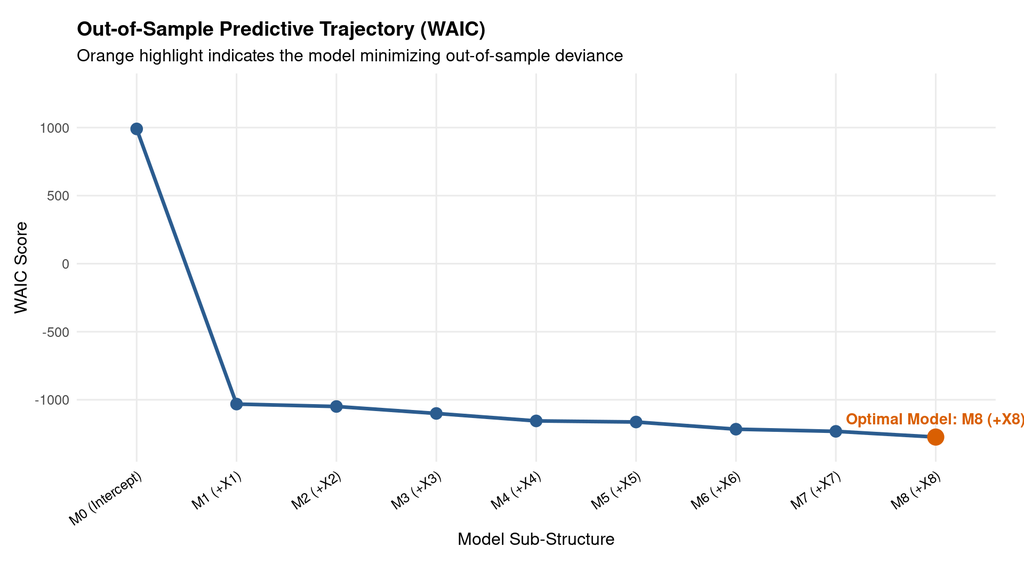

```r
# -----------------------------------------------------------------------------
# 4. Plot B: Focused WAIC Trajectory Plot with Minimum Highlight
# -----------------------------------------------------------------------------
p2 <- ggplot(seq_df, aes(x = factor(Model, levels = Model), y = WAIC, group = 1)) +
  geom_line(color = "#2b5c8f", linewidth = 1.2) +
  geom_point(color = "#2b5c8f", size = 3.5) +
  # Highlight optimal model point
  geom_point(
    data = seq_df[best_model_idx, ],
    aes(x = factor(Model, levels = Model), y = WAIC),
    color = "#d95f02", size = 5
  ) +
  annotate(
    "text",
    x = best_model_idx,
    y = seq_df$WAIC[best_model_idx] + (max(seq_df$WAIC) - min(seq_df$WAIC)) * 0.06,
    label = paste0("Optimal Model: ", seq_df$Model[best_model_idx]),
    color = "#d95f02", fontface = "bold", size = 3.8
  ) +
  # Add vertical expansion & prevent text clipping
  scale_y_continuous(expand = expansion(mult = c(0.08, 0.18))) +
  coord_cartesian(clip = "off") +
  theme_minimal(base_size = 12) +
  theme(
    axis.text.x = element_text(angle = 35, hjust = 1, color = "black"),
    panel.grid.minor = element_blank(),
    plot.title = element_text(face = "bold", size = 14),
    plot.margin = margin(t = 15, r = 20, b = 10, l = 10)
  ) +
  labs(
    title = "Out-of-Sample Predictive Trajectory (WAIC)",
    subtitle = "Orange highlight indicates the model minimizing out-of-sample deviance",
    x = "Model Sub-Structure",
    y = "WAIC Score"
  )

print(p2)
```